# Logger_Markdown

BWilliams

2023-12-06

## Introduction

Nest defense is common across animals, but distraction displays designed to lead predators away from the nest seem to be widespread only within birds. Among these, the ‘Broken Wing Display’ (BWD) is one of the most extraordinary because it involves the parent risking their own life to deceive predators from discovering their offspring. To date, we know that BWD is a widespread behavior that varies with nesting cycle, sex, and predator type3. However, we know little about the potential costs of BWD to offspring, especially since the initiation of BWD requires the incubating parent to leave the nest. My project will analyze how nest defense behaviors affect incubation patterns in Killdeer (*Charadrius vociferus*) using nest temperature data.

#### 1. Load packages

```r
library(tidyverse)
library(lubridate)
library(ggplot2)
```

#### 2. Import Logger Data

```r
Logger_2 <- read.csv("Logger 2.csv")
Logger_2 = Logger_2 %>% mutate(date_time=mdy_hm(Date.Time))

Logger_3 <- read.csv("Logger 3.csv")
Logger_3 = Logger_3 %>% mutate(date_time=mdy_hm(Date.Time))

Logger_F <- read.csv("Logger F.csv")
Logger_F = Logger_F %>% mutate(date_time=mdy_hm(Date.Time))

Logger_N <- read.csv("Logger N.csv")
Logger_N = Logger_N %>% mutate(date_time=mdy_hm(Date.Time))

#Create column to assign data to logger
Logger_N$logger="N"
Logger_F$logger="F"
Logger_2$logger="2"
Logger_3$logger="3"
```

#### 3. Combine and plot all loggers together

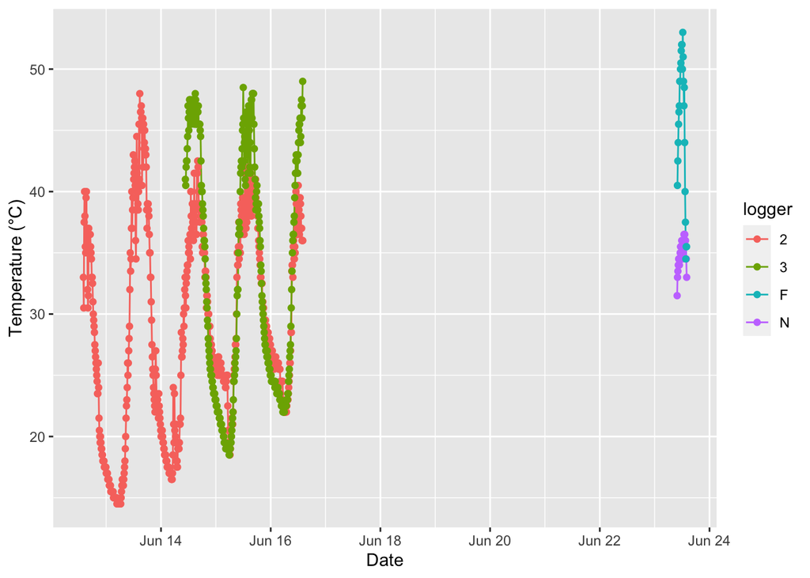

```r
Logger_All=bind_rows(Logger_N, Logger_F, Logger_2, Logger_3)

ggplot(data=Logger_All,mapping=aes(x=date_time, y=Value, group=logger, color=logger))+
  geom_path()+
  geom_point()+
  labs(x="Date", y="Temperature (\u00B0C)")
```

#### 4.a Combine, filter and plot loggers 2 and 3

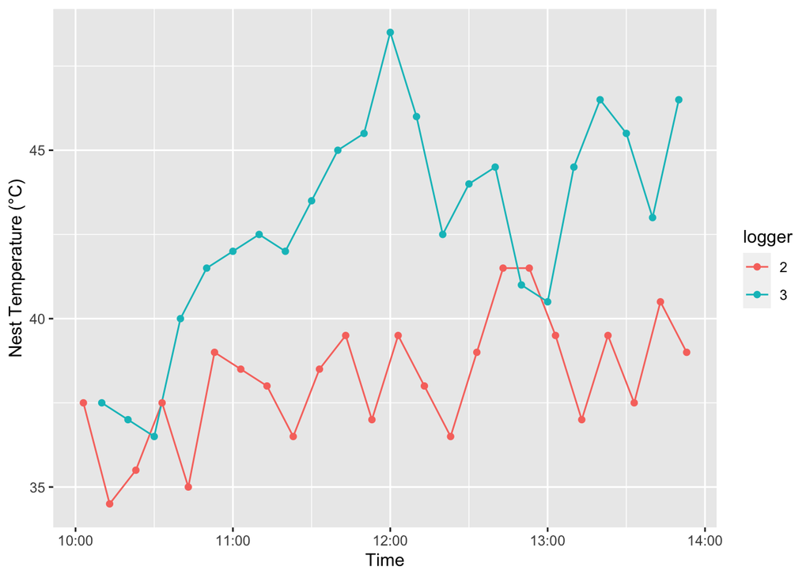

```r
Loggers_23=bind_rows(Logger_2,Logger_3)
#Filter data to match times for logger N (10am-2pm) and plot
dat23=Loggers_23 %>% filter(date_time>ymd_hms("2023-06-15 10:00:00")&date_time<ymd_hms("2023-06-15 14:00:00"))
#Create graph
ggplot(data=dat23,mapping=aes(x=date_time, y=Value, group=logger, color=logger))+
  geom_path()+
  geom_point()+
  labs(y="Nest Temperature (\u00B0C)", x="Time")
```

This graph shows how much the nest temperature changed throughout the 4-hour period.From here it can be assumed that nest #2 was being attended to more consistently than nest #3.We do know that nest #2 started with one egg and ended with four, while nest #3 started with two eggs and ended with three, so it can be assumed that these graphs also capture egg laying.

#### 4.b Create a boxplot to compare means for loggers 2 and 3

```r
ggplot(data=dat23, aes(x=logger, y=Value)) +
  geom_boxplot()+
  labs(y="Nest Temperature(\u00B0C)", x="Logger")
```

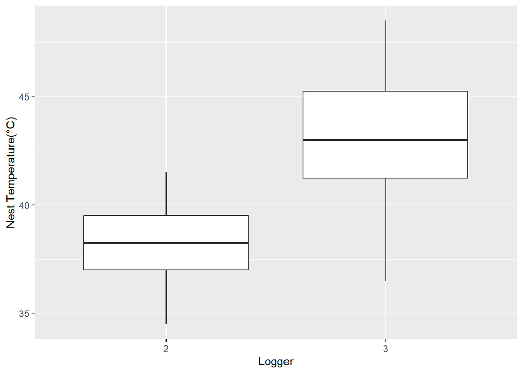

This shows that the average temperatures for nest #2 were lower than nest #3, further supporting the hypothesis that nest #2 was attended to more.

[figure not shown]

#### 5.a Combine and plot loggers N and F

```r
Logger_NF=bind_rows(Logger_N, Logger_F)

ggplot(data=Logger_NF,mapping=aes(x=date_time, y=Value, group=logger, color=logger))+
  geom_path()+
  geom_point()+
  labs(y="Nest Temperature(\u00B0C)", x="Time")
```

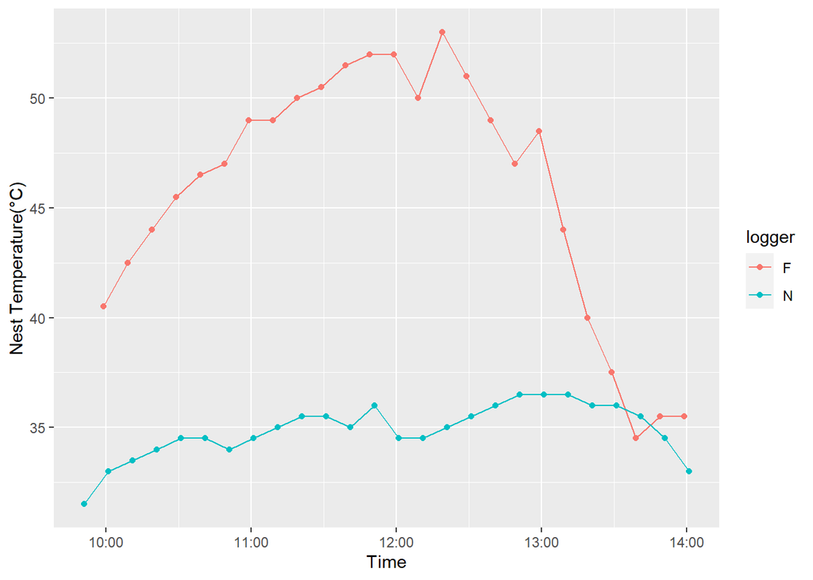

This graph is showing the differences between the ambient temperature, logger F, and nest temperature,logger N. It shows that the Killdeer was doing a good job at keeping the nest temperature lower than ambient temperatures, ensuring that the eggs didn’t overheat.

[figure not shown]

#### 5.b Create a boxplot for loggers N and F

```r
ggplot(data=Logger_NF, aes(x=logger, y=Value)) +
  geom_boxplot()+
  labs(y="Nest Temperature(\u00B0C)", x="Logger")
```

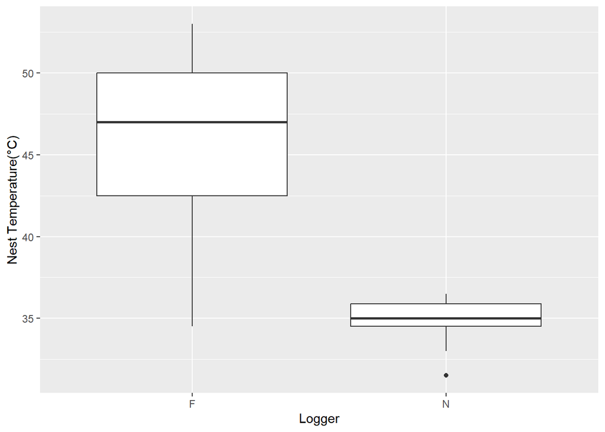

This shows that the average nest temperature (Logger N) stayed below the average ambient temperature (Logger F), exhibiting high nest attendence.

[figure not shown]

#### 5.c Perform linear regression for loggers N and F

```r
#combine Logger N & F temperature data
LogNF_temps=cbind(Logger_F$Value,Logger_N$Value)
```

```r
#convert to a data frame
datNF=as.data.frame(LogNF_temps)
#plot N vs F
ggplot(data=datNF,mapping=aes(x=V1,y=V2))+
  geom_point() +
  geom_smooth(method="lm")+
  lims(y=c(32,55), x=c(32,55))+
  labs(y="Nest Temperature",x="Ambeint Temperature")
```

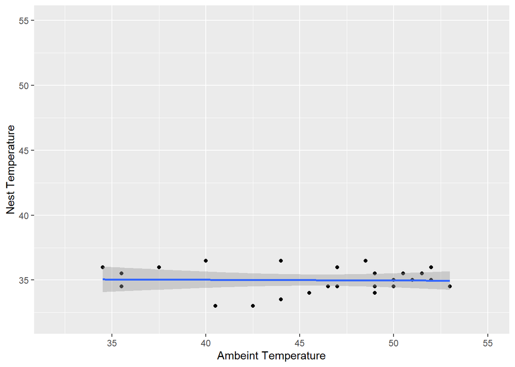

This regression shows that there is no relationship between ambient temperature and nest temperature, meaning that the Killdeer is doing a great job at keeping the nest temperatures lower than ambient temperatures.

[figure not shown]

## Discussion

Overall, this data shows that Killdeer are doing a good job at keeping their nests at temperatures below ambient temperature.The next step would be to collect more data so that we can have a representative average nest temperature, and compare it to nest temperature during nest defense behaviors to determine the risk factor involved in behaviors that require parents to get off the nest.I would also like to compare nest temperature with nesting materials used by parents to see if they have an effect on heat retention.